# Experiment 3: More Airline Data

Asynchronous Lecture

2023-09-10

Time Stamp: 32:00 Alexis Alexander

This experiment (concerptually) continues our class work on flight data.

We will continue to refer to (https://r4ds.hadley.nz/data-transform).

**However, we will expand and update our dataset by going to a root source – the Bureau of Transportation.

Go to the website https://www.transtats.bts.gov/DL_SelectFields.aspx?gnoyr_VQ=FIM&QO_fu146_anzr=Nv4%20Pn44vr45. This dataset allows access to information on domestic flight and domestic carriers, with monthly summary data.

# Packages

```r
library(nycflights13)
library(tidyverse)
library(janitor)
library(here)
```

# Get data from the online source.

Save the download to your data_raw directory. It will be a zipfile, but that will be OK. Don’t change the name on the zipfile.

## Load the BOT data

We take advantage of the here package to get the path to the file that we stored. We also may not that inside the zipfile is a csv file. We will read the csv file.

```r
thisfile=here("data_raw", "DL_SelectFields.zip")

df2022=read_csv(thisfile) %>% clean_names()
```

## Subsetting to data of interest

Let’s focus on flights from LGA and eliminate cargo flights by requiring at least 1 passenger.

Call the resultant dataframe ‘df9’.

```r
df9=df2022 |> filter(passengers>0,origin=="LGA")
```

# Exploring the BOT 2022 data

## Subsetting to data of interest

Lets try to visualize a monthly count of flights using a barchart.

First, a not quite right visualization

aes - declare what is on the horizontal, and geometry is bar

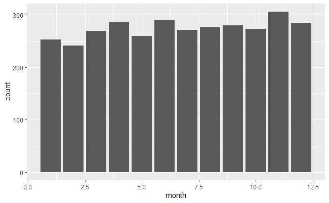

```r
df9 |>
  ggplot(aes(month)) + geom_bar()
```

This shows flights from everywhere out of LGA. The lines in tables are counting the number of departures in a month. Count the number of departures and not the number of rows.

By default, geom_bar is countign the number of rows, where we have asked it to visualize the count by moth

** Take a look at the dattset and discover why counting rows is not going to give us a count of flights***

weight each row by a certain value, weigh each row by the actual number of departures

The visualization we want is:

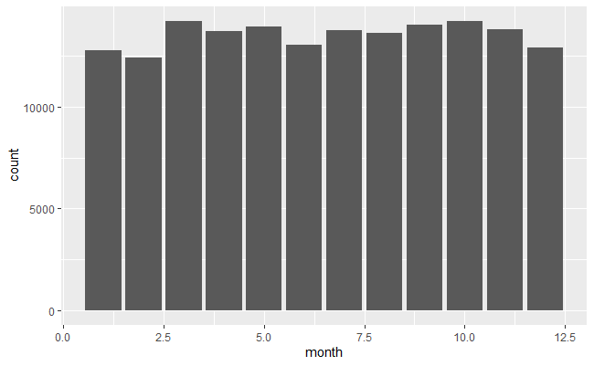

```r
df9 |> ggplot(aes(month)) + geom_bar(aes(weight=departures_performed))
```

Make some observations about this plot.

### A New Visualization

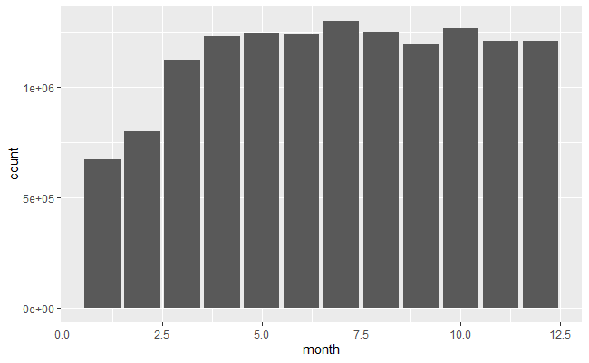

```r
df9|> ggplot(aes(month)) + geom_bar(aes(weight=passengers))
```

Observation: * Low passenger numbers in early 2022 likely due to Covid * Flights may still have been affected by the pandemic

***Just Because You Can

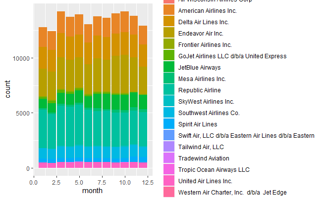

```r
df9 |>
  ggplot(aes(month, fill=carrier_name)) + geom_bar(aes(weight=departures_performed))
```

## Arrivals and Departures from LGA

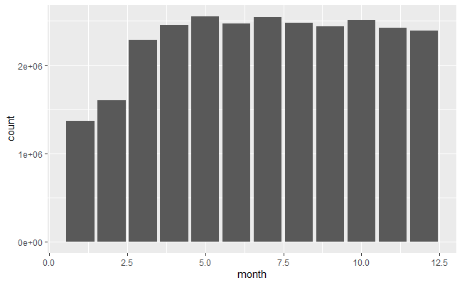

```r
df10=df2022 |> filter(passengers>0,origin=="LGA" | dest=="LGA")

df10 |> ggplot(aes(month)) + geom_bar(aes(weight=passengers))
```

originally selecting by name but could select based on a subset of these variables

```r
df11=df10 |>
  select(month,passengers,seats,carrier_name,dest,origin)
```

```r
df12=df10 |> select(1:5, month, contains("id"))
```

How full was the airplane? Distribution of how full these airlines were

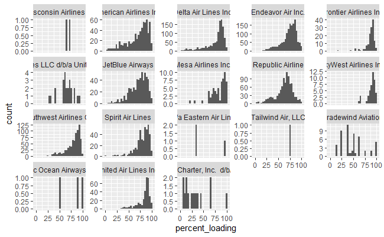

```r
df13=df11 |> mutate(percent_loading = passengers/seats*100)

df13 |>
  ggplot(aes(percent_loading)) +
  geom_histogram()+facet_wrap(~carrier_name, scales="free_y")
```